# Visualisation of proteomics data using R and Bioconductor

**Package:** *[RforProteomics](http://bioconductor.org/packages/release/data/experiment/html/RforProteomics.html)*  
**Authors:** Authors: [Laurent Gatto](http://cpu.sysbiol.cam.ac.uk/lgatto/), [Lisa Breckels](http://cpu.sysbiol.cam.ac.uk/) and [Sebastian Gibb](http://sebastiangibb.de/research.html)  
**Last compiled:** Tue Mar 24 00:44:39 2015  
**Last modified:** 2015-03-24 00:39:58

## Introduction

This vignette illustrates existing and Bioconductor infrastructure for the visualisation of mass spectrometry and proteomics data. The code details the visualisations presented in

> Gatto L, Breckels LM, Naake T, Gibb S. Visualisation of proteomics data using R and Bioconductor. Proteomics. 2015 Feb 18. doi: 10.1002/pmic.201400392. PubMed PMID: 25690415.

### References

- CRAN Task View: Graphic Displays & Dynamic Graphics & Graphic Devices & Visualization: http://cran.r-project.org/web/views/Graphics.html
- CRAN Task View: Web Technologies and Services: http://cran.r-project.org/web/views/WebTechnologies.html
- ggplot2 [book](http://link.springer.com/book/10.1007%2F978-0-387-98141-3) (syntax is slightly outdated) ([code](http://ggplot2.org/book/)), [web page](http://ggplot2.org/) and [on-line docs](http://docs.ggplot2.org/current/)
- lattice [book](http://lmdvr.r-forge.r-project.org/figures/figures.html) and [web page](http://lattice.r-forge.r-project.org/)
- *R Graphics* [book](https://www.stat.auckland.ac.nz/~paul/RG2e/)
- [R Cookbook](http://www.cookbook-r.com/Graphs/) and [R Graphics Cookbook](http://shop.oreilly.com/product/0636920023135.do)

### Relevant packages

There are currently 68 Proteomics and 49 MassSpectrometry packages in Bioconductor version 3.1. Other non-Bioconductor packages are described in the *[RforProteomics](http://bioconductor.org/packages/release/data/experiment/html/RforProteomics.html)* [vignette](http://bioconductor.org/packages/devel/data/experiment/vignettes/RforProteomics/inst/doc/RforProteomics.pdf).

|  | Package | Title | Version |
| --- | --- | --- | --- |
| ASEB | ASEB | Predict Acetylated Lysine Sites | 1.11.0 |
| bioassayR | bioassayR | R library for Bioactivity analysis | 1.5.10 |
| BRAIN | BRAIN | Baffling Recursive Algorithm for Isotope distributioN calculations | 1.13.0 |
| Cardinal | Cardinal | A mass spectrometry imaging toolbox for statistical analysis | 0.99.5 |
| CellNOptR | CellNOptR | Training of boolean logic models of signalling networks using prior knowledge networks and perturbation data. | 1.13.0 |
| ChemmineR | ChemmineR | Cheminformatics Toolkit for R | 2.19.0 |
| cisPath | cisPath | Visualization and management of the protein-protein interaction networks. | 1.7.4 |
| cleaver | cleaver | Cleavage of Polypeptide Sequences | 1.5.3 |
| clippda | clippda | A package for the clinical proteomic profiling data analysis | 1.17.0 |
| CNORdt | CNORdt | Add-on to CellNOptR: Discretized time treatments | 1.9.0 |
| CNORfeeder | CNORfeeder | Integration of CellNOptR to add missing links | 1.7.0 |
| CNORode | CNORode | ODE add-on to CellNOptR | 1.9.1 |
| customProDB | customProDB | Generate customized protein database from NGS data, with a focus on RNA-Seq data, for proteomics search. | 1.7.0 |
| deltaGseg | deltaGseg | deltaGseg | 1.7.0 |
| eiR | eiR | Accelerated similarity searching of small molecules | 1.7.2 |
| fmcsR | fmcsR | Mismatch Tolerant Maximum Common Substructure Searching | 1.9.0 |
| GraphPAC | GraphPAC | Identification of Mutational Clusters in Proteins via a Graph Theoretical Approach. | 1.9.0 |
| hpar | hpar | Human Protein Atlas in R | 1.9.1 |
| iPAC | iPAC | Identification of Protein Amino acid Clustering | 1.11.0 |
| IPPD | IPPD | Isotopic peak pattern deconvolution for Protein Mass Spectrometry by template matching | 1.15.0 |
| isobar | isobar | Analysis and quantitation of isobarically tagged MSMS proteomics data | 1.13.2 |
| LPEadj | LPEadj | A correction of the local pooled error (LPE) method to replace the asymptotic variance adjustment with an unbiased adjustment based on sample size. | 1.27.0 |
| MassSpecWavelet | MassSpecWavelet | Mass spectrum processing by wavelet-based algorithms | 1.33.0 |
| MSGFgui | MSGFgui | A shiny GUI for MSGFplus | 1.1.2 |
| MSGFplus | MSGFplus | An interface between R and MS-GF+ | 1.1.3 |
| msmsEDA | msmsEDA | Exploratory Data Analysis of LC-MS/MS data by spectral counts | 1.5.0 |
| msmsTests | msmsTests | LC-MS/MS Differential Expression Tests | 1.5.0 |
| MSnbase | MSnbase | Base Functions and Classes for MS-based Proteomics | 1.15.12 |
| MSnID | MSnID | Utilities for Exploration and Assessment of Confidence of LC-MSn Proteomics Identifications. | 1.1.3 |
| MSstats | MSstats | Protein Significance Analysis in DDA, SRM and DIA for Label-free or Label-based Proteomics Experiments | 2.5.0 |
| mzID | mzID | An mzIdentML parser for R | 1.5.2 |
| mzR | mzR | parser for netCDF, mzXML, mzData and mzML and mzIdentML files (mass spectrometry data) | 2.1.15 |
| PAA | PAA | PAA (Protein Array Analyzer) | 1.1.1 |
| PAnnBuilder | PAnnBuilder | Protein annotation data package builder | 1.31.1 |
| pathview | pathview | a tool set for pathway based data integration and visualization | 1.7.0 |
| Pbase | Pbase | Manipulating and exploring protein and proteomics data | 0.6.12 |
| PCpheno | PCpheno | Phenotypes and cellular organizational units | 1.29.0 |
| pepXMLTab | pepXMLTab | Parsing pepXML files and filter based on peptide FDR. | 1.1.0 |
| plgem | plgem | Detect differential expression in microarray and proteomics datasets with the Power Law Global Error Model (PLGEM) | 1.39.1 |
| PLPE | PLPE | Local Pooled Error Test for Differential Expression with Paired High-throughput Data | 1.27.0 |
| ppiStats | ppiStats | Protein-Protein Interaction Statistical Package | 1.33.0 |
| proBAMr | proBAMr | Generating SAM file for PSMs in shotgun proteomics data. | 1.1.2 |
| PROcess | PROcess | Ciphergen SELDI-TOF Processing | 1.43.0 |
| procoil | procoil | Prediction of Oligomerization of Coiled Coil Proteins | 1.17.0 |
| ProCoNA | ProCoNA | Protein co-expression network analysis (ProCoNA). | 1.5.2 |
| pRoloc | pRoloc | A unifying bioinformatics framework for spatial proteomics | 1.7.5 |
| pRolocGUI | pRolocGUI | Interactive visualisation of spatial proteomics data | 1.1.4 |
| prot2D | prot2D | Statistical Tools for volume data from 2D Gel Electrophoresis | 1.5.0 |
| proteoQC | proteoQC | An R package for proteomics data quality control | 1.3.2 |
| ProtGenerics | ProtGenerics | S4 generic functions for Bioconductor proteomics infrastructure | 0.99.3 |
| Pviz | Pviz | Peptide Annotation and Data Visualization using Gviz | 1.1.1 |
| qcmetrics | qcmetrics | A Framework for Quality Control | 1.5.1 |
| QuartPAC | QuartPAC | Identification of mutational clusters in protein quaternary structures. | 0.99.3 |
| rain | rain | Rhythmicity Analysis Incorporating Non-parametric Methods | 1.1.1 |
| RCASPAR | RCASPAR | A package for survival time prediction based on a piecewise baseline hazard Cox regression model. | 1.13.0 |
| Rchemcpp | Rchemcpp | Similarity measures for chemical compounds | 2.5.0 |
| Rcpi | Rcpi | Toolkit for Compound-Protein Interaction in Drug Discovery | 1.3.0 |
| RpsiXML | RpsiXML | R interface to PSI-MI 2.5 files | 2.9.0 |
| rpx | rpx | R Interface to the ProteomeXchange Repository | 1.3.0 |
| rTANDEM | rTANDEM | Interfaces the tandem protein identification algorithm in R | 1.7.0 |
| sapFinder | sapFinder | A package for variant peptides detection and visualization in shotgun proteomics. | 1.5.10 |
| ScISI | ScISI | In Silico Interactome | 1.39.0 |
| shinyTANDEM | shinyTANDEM | Provides a GUI for rTANDEM | 1.5.0 |
| SLGI | SLGI | Synthetic Lethal Genetic Interaction | 1.27.0 |
| SpacePAC | SpacePAC | Identification of Mutational Clusters in 3D Protein Space via Simulation. | 1.5.0 |
| specL | specL | specL - Prepare Peptide Spectrum Matches for Use in Targeted Proteomics | 1.1.14 |
| spliceSites | spliceSites | Manages align gap positions from RNA-seq data | 1.5.0 |
| synapter | synapter | Label-free data analysis pipeline for optimal identification and quantitation | 1.9.4 |

|  | Package | Title | Version |
| --- | --- | --- | --- |
| apComplex | apComplex | Estimate protein complex membership using AP-MS protein data | 2.33.0 |
| BRAIN | BRAIN | Baffling Recursive Algorithm for Isotope distributioN calculations | 1.13.0 |
| CAMERA | CAMERA | Collection of annotation related methods for mass spectrometry data | 1.23.2 |
| Cardinal | Cardinal | A mass spectrometry imaging toolbox for statistical analysis | 0.99.5 |
| cosmiq | cosmiq | cosmiq - COmbining Single Masses Into Quantities | 1.1.0 |
| cytofkit | cytofkit | cytofkit: an integrated analysis pipeline for mass cytometry data | 0.99.18 |
| flagme | flagme | Analysis of Metabolomics GC/MS Data | 1.23.1 |
| gaga | gaga | GaGa hierarchical model for high-throughput data analysis | 2.13.0 |
| iontree | iontree | Data management and analysis of ion trees from ion-trap mass spectrometry | 1.13.0 |
| isobar | isobar | Analysis and quantitation of isobarically tagged MSMS proteomics data | 1.13.2 |
| MAIT | MAIT | Statistical Analysis of Metabolomic Data | 1.1.0 |
| MassArray | MassArray | Analytical Tools for MassArray Data | 1.19.0 |
| MassSpecWavelet | MassSpecWavelet | Mass spectrum processing by wavelet-based algorithms | 1.33.0 |
| Metab | Metab | Metab: An R Package for a High-Throughput Analysis of Metabolomics Data Generated by GC-MS. | 1.1.0 |
| metabomxtr | metabomxtr | A package to run mixture models for truncated metabolomics data with normal or lognormal distributions. | 1.1.0 |
| metaMS | metaMS | MS-based metabolomics annotation pipeline | 1.3.5 |
| MSGFgui | MSGFgui | A shiny GUI for MSGFplus | 1.1.2 |
| MSGFplus | MSGFplus | An interface between R and MS-GF+ | 1.1.3 |
| msmsEDA | msmsEDA | Exploratory Data Analysis of LC-MS/MS data by spectral counts | 1.5.0 |
| msmsTests | msmsTests | LC-MS/MS Differential Expression Tests | 1.5.0 |
| MSnbase | MSnbase | Base Functions and Classes for MS-based Proteomics | 1.15.12 |
| MSnID | MSnID | Utilities for Exploration and Assessment of Confidence of LC-MSn Proteomics Identifications. | 1.1.3 |
| MSstats | MSstats | Protein Significance Analysis in DDA, SRM and DIA for Label-free or Label-based Proteomics Experiments | 2.5.0 |
| mzID | mzID | An mzIdentML parser for R | 1.5.2 |
| mzR | mzR | parser for netCDF, mzXML, mzData and mzML and mzIdentML files (mass spectrometry data) | 2.1.15 |
| PAPi | PAPi | Predict metabolic pathway activity based on metabolomics data | 1.7.0 |
| Pbase | Pbase | Manipulating and exploring protein and proteomics data | 0.6.12 |
| pepXMLTab | pepXMLTab | Parsing pepXML files and filter based on peptide FDR. | 1.1.0 |
| plgem | plgem | Detect differential expression in microarray and proteomics datasets with the Power Law Global Error Model (PLGEM) | 1.39.1 |
| proBAMr | proBAMr | Generating SAM file for PSMs in shotgun proteomics data. | 1.1.2 |
| PROcess | PROcess | Ciphergen SELDI-TOF Processing | 1.43.0 |
| pRoloc | pRoloc | A unifying bioinformatics framework for spatial proteomics | 1.7.5 |
| proteoQC | proteoQC | An R package for proteomics data quality control | 1.3.2 |
| ProtGenerics | ProtGenerics | S4 generic functions for Bioconductor proteomics infrastructure | 0.99.3 |
| qcmetrics | qcmetrics | A Framework for Quality Control | 1.5.1 |
| Rdisop | Rdisop | Decomposition of Isotopic Patterns | 1.27.0 |
| Risa | Risa | Converting experimental metadata from ISA-tab into Bioconductor data structures | 1.9.1 |
| RMassBank | RMassBank | Workflow to process tandem MS files and build MassBank records | 1.9.1 |
| rols | rols | An R interface to the Ontology Lookup Service | 1.9.0 |
| rpx | rpx | R Interface to the ProteomeXchange Repository | 1.3.0 |
| rTANDEM | rTANDEM | Interfaces the tandem protein identification algorithm in R | 1.7.0 |
| sapFinder | sapFinder | A package for variant peptides detection and visualization in shotgun proteomics. | 1.5.10 |
| shinyTANDEM | shinyTANDEM | Provides a GUI for rTANDEM | 1.5.0 |
| sidap | sidap | sidap: an integrated analysis pipeline for mass cytometry data | 0.99.9 |
| SIMAT | SIMAT | GC-SIM-MS data processing and alaysis tool | 0.99.3 |
| specL | specL | specL - Prepare Peptide Spectrum Matches for Use in Targeted Proteomics | 1.1.14 |
| synapter | synapter | Label-free data analysis pipeline for optimal identification and quantitation | 1.9.4 |
| TargetSearch | TargetSearch | A package for the analysis of GC-MS metabolite profiling data. | 1.23.0 |
| xcms | xcms | LC/MS and GC/MS Data Analysis | 1.43.3 |

## Ascombe’s quartet

| x1 | x2 | x3 | x4 | y1 | y2 | y3 | y4 |
| --- | --- | --- | --- | --- | --- | --- | --- |
| 10 | 10 | 10 | 8 | 8.04 | 9.14 | 7.46 | 6.58 |
| 8 | 8 | 8 | 8 | 6.95 | 8.14 | 6.77 | 5.76 |
| 13 | 13 | 13 | 8 | 7.58 | 8.74 | 12.74 | 7.71 |
| 9 | 9 | 9 | 8 | 8.81 | 8.77 | 7.11 | 8.84 |
| 11 | 11 | 11 | 8 | 8.33 | 9.26 | 7.81 | 8.47 |
| 14 | 14 | 14 | 8 | 9.96 | 8.10 | 8.84 | 7.04 |
| 6 | 6 | 6 | 8 | 7.24 | 6.13 | 6.08 | 5.25 |
| 4 | 4 | 4 | 19 | 4.26 | 3.10 | 5.39 | 12.50 |
| 12 | 12 | 12 | 8 | 10.84 | 9.13 | 8.15 | 5.56 |
| 7 | 7 | 7 | 8 | 4.82 | 7.26 | 6.42 | 7.91 |
| 5 | 5 | 5 | 8 | 5.68 | 4.74 | 5.73 | 6.89 |

```r
tab <- matrix(NA, 5, 4)
colnames(tab) <- 1:4
rownames(tab) <- c("var(x)", "mean(x)",
                   "var(y)", "mean(y)",
                   "cor(x,y)")

for (i in 1:4)
    tab[, i] <- c(var(anscombe[, i]),
                  mean(anscombe[, i]),
                  var(anscombe[, i+4]),
                  mean(anscombe[, i+4]),
                  cor(anscombe[, i], anscombe[, i+4]))
```

|  | 1 | 2 | 3 | 4 |
| --- | --- | --- | --- | --- |
| var(x) | 11.0000000 | 11.0000000 | 11.0000000 | 11.0000000 |
| mean(x) | 9.0000000 | 9.0000000 | 9.0000000 | 9.0000000 |
| var(y) | 4.1272691 | 4.1276291 | 4.1226200 | 4.1232491 |
| mean(y) | 7.5009091 | 7.5009091 | 7.5000000 | 7.5009091 |
| cor(x,y) | 0.8164205 | 0.8162365 | 0.8162867 | 0.8165214 |

While the residuals of the linear regression clearly indicate fundamental differences in these data, the most simple and straightforward approach is visualisation to highlight the fundamental differences in the datasets.

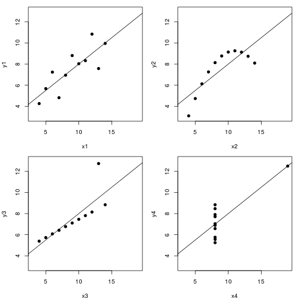

| lm1 | lm2 | lm3 | lm4 |
| --- | --- | --- | --- |
| 0.0390000 | 1.1390909 | -0.5397273 | -0.421 |
| -0.0508182 | 1.1390909 | -0.2302727 | -1.241 |
| -1.9212727 | -0.7609091 | 3.2410909 | 0.709 |
| 1.3090909 | 1.2690909 | -0.3900000 | 1.839 |
| -0.1710909 | 0.7590909 | -0.6894545 | 1.469 |
| -0.0413636 | -1.9009091 | -1.1586364 | 0.039 |
| 1.2393636 | 0.1290909 | 0.0791818 | -1.751 |
| -0.7404545 | -1.9009091 | 0.3886364 | 0.000 |
| 1.8388182 | 0.1290909 | -0.8491818 | -1.441 |
| -1.6807273 | 0.7590909 | -0.0805455 | 0.909 |
| 0.1794545 | -0.7609091 | 0.2289091 | -0.111 |

```r
ff <- y ~ x

mods <- setNames(as.list(1:4), paste0("lm", 1:4))

par(mfrow = c(2, 2), mar = c(4, 4, 1, 1))
for (i in 1:4) {
    ff[2:3] <- lapply(paste0(c("y","x"), i), as.name)
    plot(ff, data = anscombe, pch = 19, xlim = c(3, 19), ylim = c(3, 13))
    mods[[i]] <- lm(ff, data = anscombe)
    abline(mods[[i]])
}
```

## The MA plot example

The following code chunk connects to the `PXD000001` data set on the ProteomeXchange repository and fetches the `mzTab` file. After missing values filtering, we extract relevant data (log2 fold-changes and log10 mean expression intensities) into `data.frames`.

```r
library("rpx")
px1 <- PXDataset("PXD000001")
mztab <- pxget(px1, "PXD000001_mztab.txt")
```

```
## PXD000001_mztab.txt already present.
```

```r
library("MSnbase")
qnt <- readMzTabData(mztab, what = "PEP")
```

```
## Detected a metadata section
## Detected a peptide section
```

```r
sampleNames(qnt) <- reporterNames(TMT6)
qnt <- filterNA(qnt)
## may be combineFeatuers

spikes <- c("P02769", "P00924", "P62894", "P00489")
protclasses <- as.character(fData(qnt)$accession)
protclasses[!protclasses %in% spikes] <- "Background"


madata42 <- data.frame(A = rowMeans(log(exprs(qnt[, c(4, 2)]), 10)),
                       M = log(exprs(qnt)[, 4], 2) - log(exprs(qnt)[, 2], 2),
                       data = rep("4vs2", nrow(qnt)),
                       protein = fData(qnt)$accession,
                       class = protclasses)

madata62 <- data.frame(A = rowMeans(log(exprs(qnt[, c(6, 2)]), 10)),
                       M = log(exprs(qnt)[, 6], 2) - log(exprs(qnt)[, 2], 2),
                       data = rep("6vs2", nrow(qnt)),
                       protein = fData(qnt)$accession,
                       class = protclasses)


madata <- rbind(madata42, madata62)
```

### The traditional plotting system

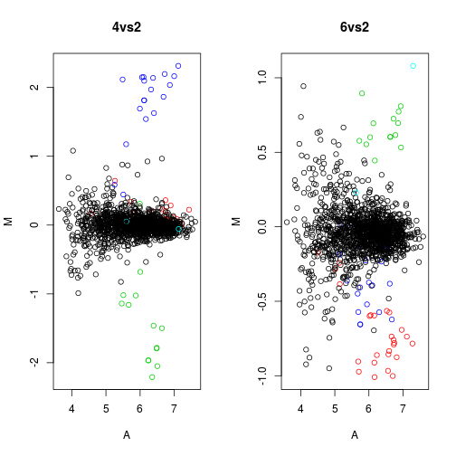

```r
par(mfrow = c(1, 2))
plot(M ~ A, data = madata42, main = "4vs2",
     xlab = "A", ylab = "M", col = madata62$class)
plot(M ~ A, data = madata62, main = "6vs2",
     xlab = "A", ylab = "M", col = madata62$class)
```

### lattice

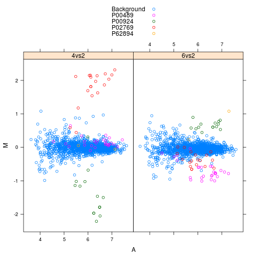

```r
library("lattice")
latma <- xyplot(M ~ A | data, data = madata,
                groups = madata$class,
                auto.key = TRUE)
print(latma)
```

### ggplot2

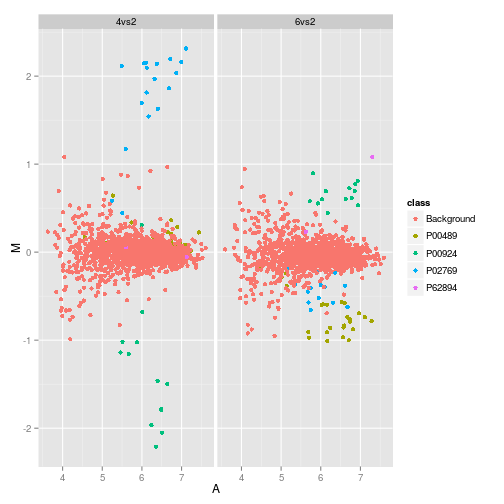

```r
library("ggplot2")
ggma <- ggplot(aes(x = A, y = M, colour = class), data = madata,
               colour = class) +
                   geom_point() +
                       facet_grid(. ~ data)
print(ggma)
```

### Customization

```r
library("RColorBrewer")
bcols <- brewer.pal(4, "Set1")
cls <- c("Background" = "#12121230",
         "P02769" = bcols[1],
         "P00924" = bcols[2],
         "P62894" = bcols[3],
         "P00489" = bcols[4])
```

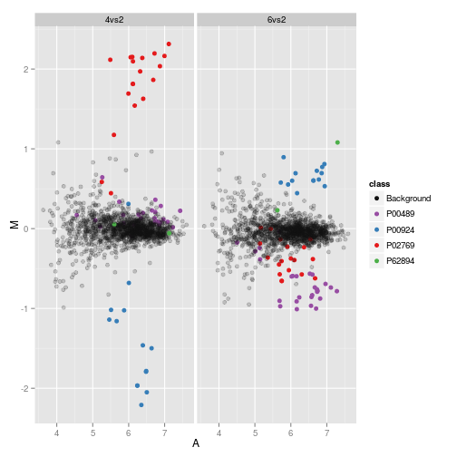

```r
ggma2 <- ggplot(aes(x = A, y = M, colour = class),
                data = madata) + geom_point(shape = 19) +
                    facet_grid(. ~ data) + scale_colour_manual(values = cls) +
                        guides(colour = guide_legend(override.aes = list(alpha = 1)))
print(ggma2)
```

### The `MAplot` method for `MSnSet` instances

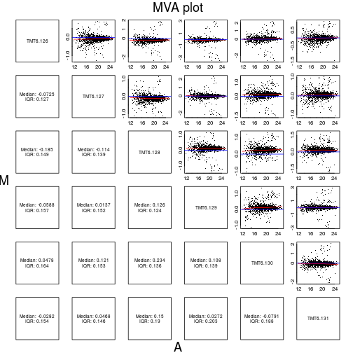

```r
MAplot(qnt, cex = .8)
```

### An interactive *[shiny](http://cran.fhcrc.org/web/packages/shiny/index.html)* app for MA plots

This app is based on Mike Love’s shinyMA application, adapted for a proteomics data. A screen shot is displayed below. To start the application:

```r
shinyMA()
```

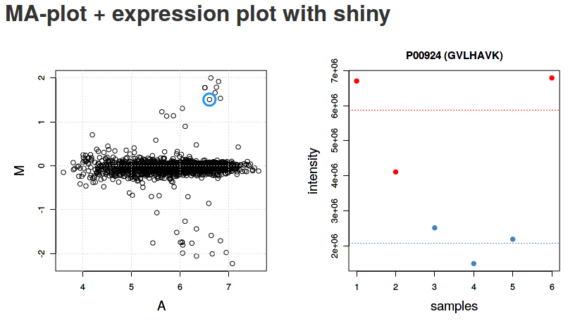

The application is also available online at https://lgatto.shinyapps.io/shinyMA/.

See the excellent *[shiny](http://cran.fhcrc.org/web/packages/shiny/index.html)* [web page](http://shiny.rstudio.com/) for tutorials.

### Volcano plots

```r
library("msmsEDA")
library("msmsTests")
data(msms.dataset)
## Pre-process expression matrix
e <- pp.msms.data(msms.dataset)
## Models and normalizing condition
null.f <- "y~batch"
alt.f <- "y~treat+batch"
div <- apply(exprs(e),2,sum)
## Test
res <- msms.glm.qlll(e,alt.f,null.f,div=div)
lst <- test.results(res,e,pData(e)$treat,"U600","U200",div,
                    alpha=0.05,minSpC=2,minLFC=log2(1.8),
                    method="BH")
```

Here, we produce the volcano plot by hand, with the `plot` function. In the second plot, we limit the x axis limits and add grid lines.

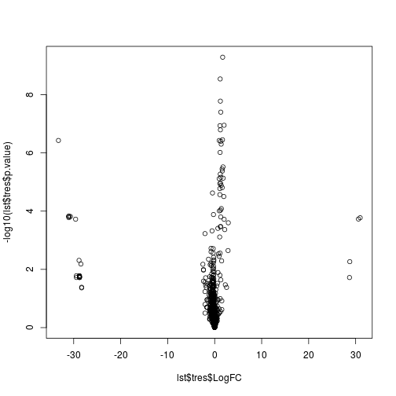

```r
plot(lst$tres$LogFC, -log10(lst$tres$p.value))
```

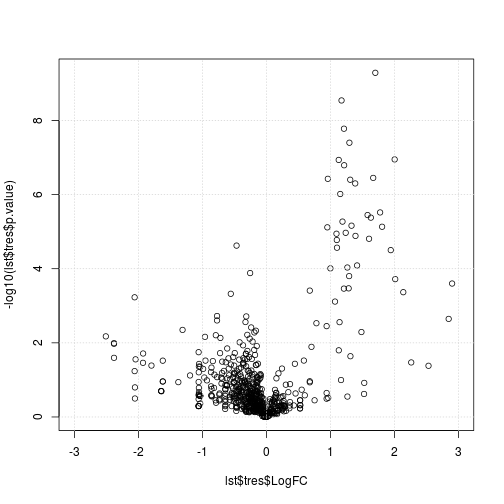

```r
plot(lst$tres$LogFC, -log10(lst$tres$p.value),
     xlim = c(-3, 3))
grid()
```

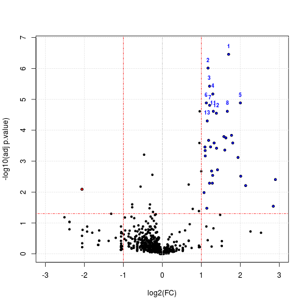

```r
## Plot
res.volcanoplot(lst$tres,
                max.pval=0.05,
                min.LFC=1,
                maxx=3,
                maxy=NULL,
                ylbls=4)
```

### A PCA plot

Using the `counts.pca` function from the *[msmsEDA](http://bioconductor.org/packages/release/bioc/html/msmsEDA.html)* package:

```r
library("msmsEDA")
data(msms.dataset)
msnset <- pp.msms.data(msms.dataset)
lst <- counts.pca(msnset, wait=FALSE)
```

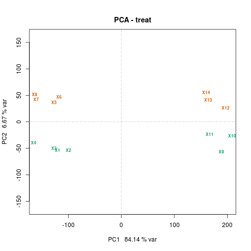

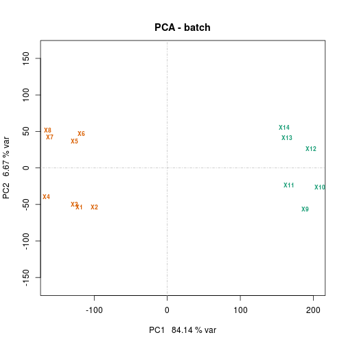

It is also possible to generate the PCA data using the `prcomp`. Below, we extract the coordinates of PC1 and PC2 from the `counts.pca` result and plot them using the `plot` function.

```r
pcadata <- lst$pca$x[, 1:2]
head(pcadata)
```

```
##                  PC1       PC2
## U2.2502.1 -120.26080 -53.55270
## U2.2502.2  -99.90618 -53.89979
## U2.2502.3 -127.35928 -49.29906
## U2.2502.4 -166.04611 -39.27557
## U6.2502.1 -127.18423  37.11614
## U6.2502.2 -117.97016  47.03702
```

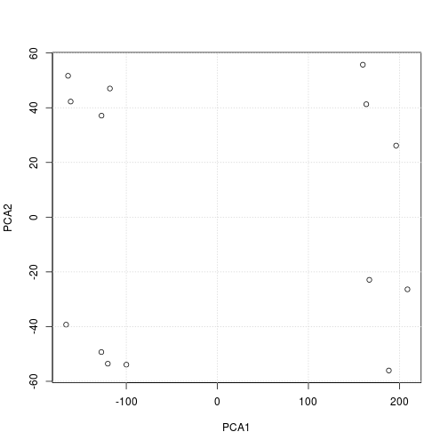

```r
plot(pcadata[, 1], pcadata[, 2],
     xlab = "PCA1", ylab = "PCA2")
grid()
```

## Plotting with R

```r
kable(plotfuns)
```

| plot type | traditional | lattice | ggplot2 |
| --- | --- | --- | --- |
| scatterplots | plot | xyplot | geom_point |
| histograms | hist | histgram | geom_histogram |
| density plots | plot(density()) | densityplot | geom_density |
| boxplots | boxplot | bwplot | geom_boxplot |
| violin plots | vioplot::vioplot | bwplot(…, panel = panel.violin) | geom_violin |
| line plots | plot, matplot | xyploy, parallelplot | geom_line |
| bar plots | barplot | barchart | geom_bar |
| pie charts | pie |  | geom_bar with polar coordinates |
| dot plots | dotchart | dotplot | geom_point |
| stip plots | stripchart | stripplot | goem_point |
| dendrogramms | plot(hclust()) | latticeExtra package | ggdendro package |
| heatmaps | image, heatmap | levelplot | geom_tile |

```r
library("pRolocdata")
data(tan2009r1)
```

### Scatter plots

See the MA and volcano plot examples.

The default plot `type` is `p`, for points. Other important types are `l` for lines and `h` for *histogram* (see below).

### Historams and density plots

We extract the (normalised) intensities of the first sample

```r
x <- exprs(tan2009r1)[, 1]
```

and plot the distribution with a histogram and a density plot next to each other on the same figure (using the `mfrow` `par` plotting paramter)

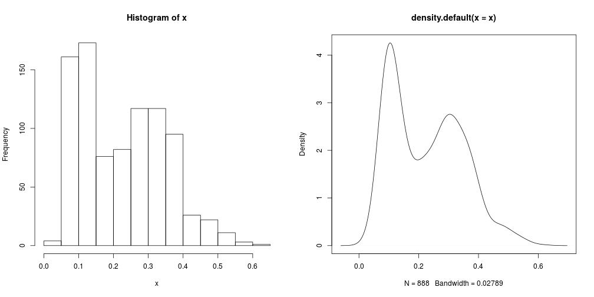

```r
par(mfrow = c(1, 2))
hist(x)
plot(density(x))
```

### box plots and violin plots

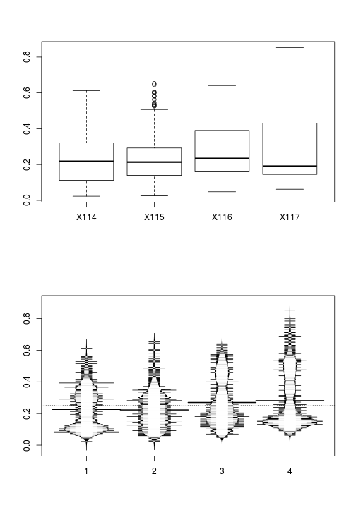

```r
library("beanplot")
x <- exprs(tan2009r1)
par(mfrow = c(2, 1))
boxplot(x)
beanplot(x[, 1], x[, 2], x[, 3], x[, 4], log = "")
```

### line plots

below, we produce line plots that describe the protein quantitative profiles for two sets of proteins, namely er and mitochondrial proteins using `matplot`.

we need to transpose the matrix (with `t`) and set the type to both (`b`), to display points and lines, the colours to red and steel blue, the point characters to 1 (an empty point) and the line type to 1 (a solid line).

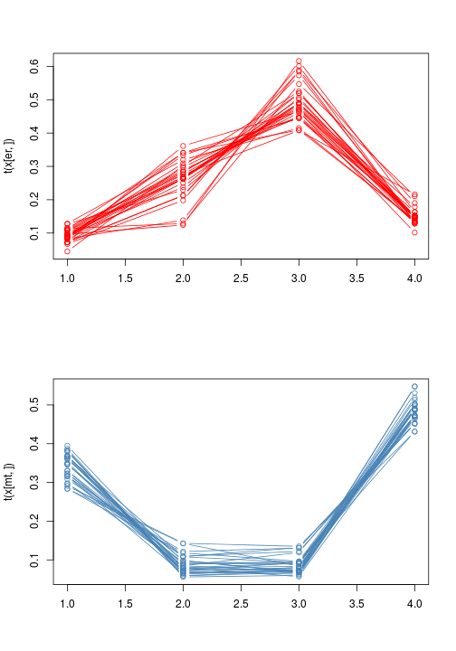

```r
er <- fData(tan2009r1)$markers == "ER"
mt <- fData(tan2009r1)$markers == "mitochondrion"

par(mfrow = c(2, 1))
matplot(t(x[er, ]), type = "b", col = "red", pch = 1, lty = 1)
matplot(t(x[mt, ]), type = "b", col = "steelblue", pch = 1, lty = 1)
```

In the last section, about spatial proteomics, we use the specialised `plotDist` function from the *[pRoloc](http://bioconductor.org/packages/release/bioc/html/pRoloc.html)* package to generate such figures.

### Bar and dot charts

To illustrate bar and dot charts, we cound the number of proteins in the respective class using table.

```r
x <- table(fData(tan2009r1)$markers)
x
```

```
##
##  Cytoskeleton            ER         Golgi      Lysosome mitochondrion
##             7            28            13             8            29
##       Nucleus    Peroxisome            PM    Proteasome  Ribosome 40S
##            21             4            34            15            20
##  Ribosome 60S       unknown
##            32           677
```

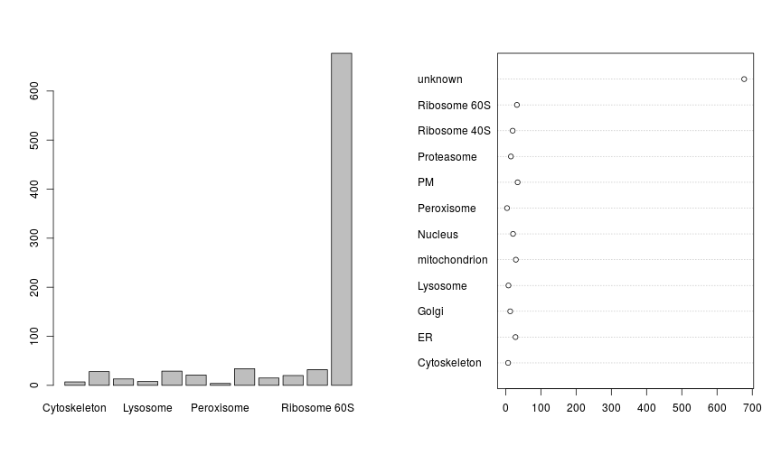

```r
par(mfrow = c(1, 2))
barplot(x)
dotchart(x)
```

### Heatmaps

The easiest to produce a complete heatmap is with the `heatmap` function:

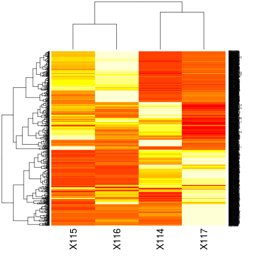

```r
heatmap(exprs(tan2009r1))
```

To produce the a heatmap without the dendrograms, one can use the image function on a matrix or the specialised version for `MSnSet` objects from the *[MSnbase](http://bioconductor.org/packages/release/bioc/html/MSnbase.html)* package.

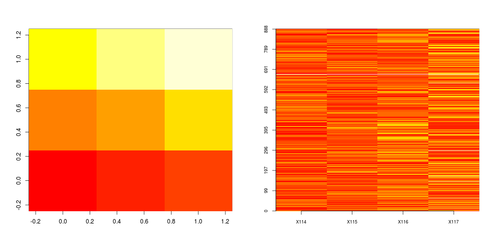

```r
par(mfrow = c(1, 2))
x <- matrix(1:9, ncol = 3)
image(x)
image(tan2009r1)
```

See also *[gplots](http://cran.fhcrc.org/web/packages/gplots/index.html)*’s `heatmap.2` function and the *[Heatplus](http://bioconductor.org/packages/release/bioc/html/Heatplus.html)* Bioconductor package for more advanced heatmaps and the *[corrplot](http://cran.fhcrc.org/web/packages/corrplot/index.html)* package for correlation matrices.

### Dendrograms

The easiest way to produce and plot a dendrogram is:

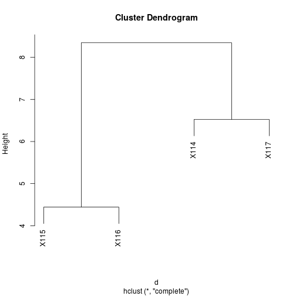

```r
d <- dist(t(exprs(tan2009r1))) ## distance between samples
hc <- hclust(d) ## hierarchical clustering
plot(hc) ## visualisation
```

See also *[dendextend](http://cran.fhcrc.org/web/packages/dendextend/index.html)* and this [post](http://stackoverflow.com/questions/6673162/reproducing-lattice-dendrogram-graph-with-ggplot2) to illustrate *[latticeExtra](http://cran.fhcrc.org/web/packages/latticeExtra/index.html)* and *[ggdendro](http://cran.fhcrc.org/web/packages/ggdendro/index.html)*.

### Venn diagrams

- The *[limma](http://bioconductor.org/packages/release/bioc/html/limma.html)* package.
- The *[VennDiagram](http://cran.fhcrc.org/web/packages/VennDiagram/index.html)* package.

## Visualising mass spectrometry data

### Direct access to the raw data

```r
library("mzR")
mzf <- pxget(px1, 6)
```

```
## TMT_Erwinia_1uLSike_Top10HCD_isol2_45stepped_60min_01-20141210.mzML already present.
```

```r
ms <- openMSfile(mzf)

hd <- header(ms)
ms1 <- which(hd$msLevel == 1)

rtsel <- hd$retentionTime[ms1] / 60 > 30 & hd$retentionTime[ms1] / 60 < 35
library("MSnbase")
(M <- MSmap(ms, ms1[rtsel], 521, 523, .005, hd))
```

```
## 1
```

```
## Object of class "MSmap"
##  Map [75, 401]
##   [1]  Retention time: 30:1 - 34:58
##   [2]  M/Z: 521 - 523 (res 0.005)
```

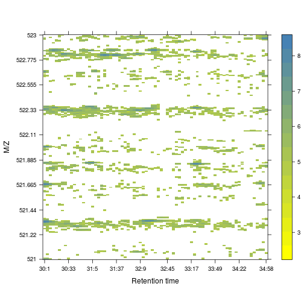

```r
library("lattice")
ff <- colorRampPalette(c("yellow", "steelblue"))
trellis.par.set(regions=list(col=ff(100)))
plot(M, aspect = 1, allTicks = FALSE)
```

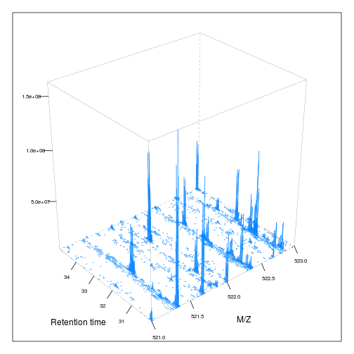

```r
M@map[msMap(M) == 0] <- NA
plot3D(M, rgl = FALSE)
```

To produce a version that can be reoriented interactively on the screen discplay, use the *[rgl](http://cran.fhcrc.org/web/packages/rgl/index.html)*

```r
library("rgl")
plot3D(M, rgl = TRUE)
```

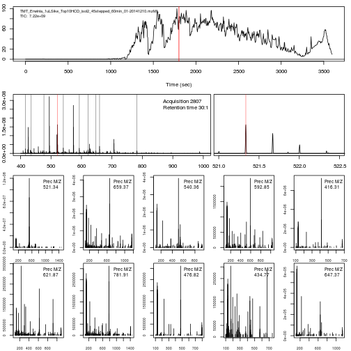

```r
lout <- matrix(NA, ncol = 10, nrow = 8)
lout[1:2, ] <- 1
for (ii in 3:4)
    lout[ii, ] <- c(2, 2, 2, 2, 2, 2, 3, 3, 3, 3)
lout[5, ] <- rep(4:8, each = 2)
lout[6, ] <- rep(4:8, each = 2)
lout[7, ] <- rep(9:13, each = 2)
lout[8, ] <- rep(9:13, each = 2)

i <- ms1[which(rtsel)][1]
j <- ms1[which(rtsel)][2]
ms2 <- (i+1):(j-1)

layout(lout)

par(mar=c(4,2,1,1))
chromatogram(ms)
abline(v = hd[i, "retentionTime"], col = "red")


par(mar = c(3, 2, 1, 0))
plot(peaks(ms, i), type = "l", xlim = c(400, 1000))
legend("topright", bty = "n",
       legend = paste0(
           "Acquisition ", hd[i, "acquisitionNum"],  "\n",
           "Retention time ", formatRt(hd[i, "retentionTime"])))
abline(h = 0)
abline(v = hd[ms2, "precursorMZ"],
       col = c("#FF000080",
           rep("#12121280", 9)))

par(mar = c(3, 0.5, 1, 1))
plot(peaks(ms, i), type = "l", xlim = c(521, 522.5),
     yaxt = "n")
abline(h = 0)
abline(v = hd[ms2, "precursorMZ"], col = "#FF000080")

##par(mar = omar)
par(mar = c(2, 2, 0, 1))
for (ii in ms2) {
    p <- peaks(ms, ii)
    plot(p, xlab = "", ylab = "", type = "h", cex.axis = .6)
    legend("topright", legend = paste0("Prec M/Z\n",
                           round(hd[ii, "precursorMZ"], 2)),
           bty = "n", cex = .8)
}
```

```r
M2 <- MSmap(ms, i:j, 100, 1000, 1, hd)
```

```
## 1
```

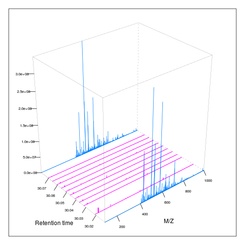

```r
plot3D(M2)
```

#### MS barcoding

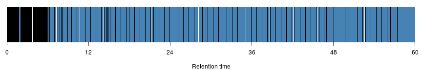

```r
par(mar=c(4,1,1,1))
image(t(matrix(hd$msLevel, 1, nrow(hd))),
      xlab="Retention time",
      xaxt="n", yaxt="n", col=c("black","steelblue"))
k <- round(range(hd$retentionTime) / 60)
nk <- 5
axis(side=1, at=seq(0,1,1/nk), labels=seq(k[1],k[2],k[2]/nk))
```

#### Animation

The following animation scrolls over 5 minutes of retention time for a MZ range between 521 and 523.

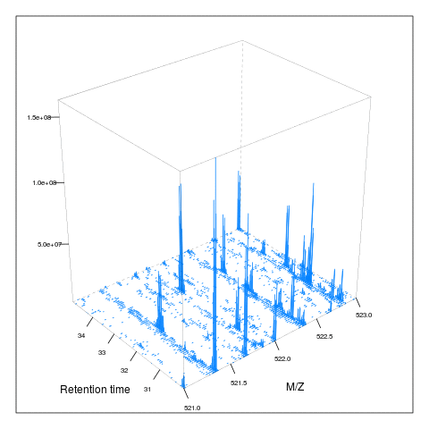

```r
library("animation")
an1 <- function() {
    for (i in seq(0, 5, 0.2)) {
        rtsel <- hd$retentionTime[ms1] / 60 > (30 + i) &
            hd$retentionTime[ms1] / 60 < (35 + i)
        M <- MSmap(ms, ms1[rtsel], 521, 523, .005, hd)
        M@map[msMap(M) == 0] <- NA
        print(plot3D(M, rgl = FALSE))
    }
}

saveGIF(an1(), movie.name = "msanim1.gif")
```

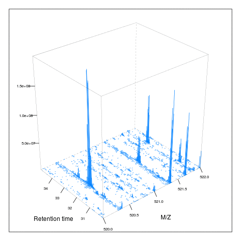

```r
an2 <- function() {
    for (i in seq(0, 2.5, 0.1)) {
        rtsel <- hd$retentionTime[ms1] / 60 > 30 & hd$retentionTime[ms1] / 60 < 35
        mz1 <- 520 + i
        mz2 <- 522 + i
        M <- MSmap(ms, ms1[rtsel], mz1, mz2, .005, hd)
        M@map[msMap(M) == 0] <- NA
        print(plot3D(M, rgl = FALSE))
    }
}

saveGIF(an2(), movie.name = "msanim2.gif")
```

### The *[MSnbase](http://bioconductor.org/packages/release/bioc/html/MSnbase.html)* infrastructure

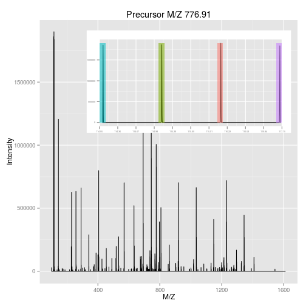

```r
library("MSnbase")
data(itraqdata)
itraqdata2 <- pickPeaks(itraqdata, verbose = FALSE)
plot(itraqdata[[25]], full=TRUE, reporters = iTRAQ4)
```

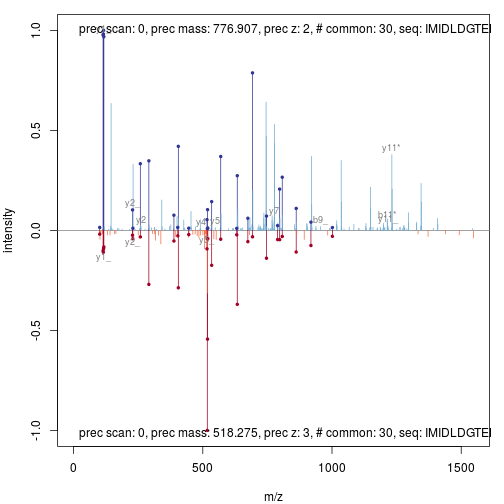

```r
par(oma = c(0, 0, 0, 0))
par(mar = c(4, 4, 1, 1))
plot(itraqdata2[[25]], itraqdata2[[28]], sequences = rep("IMIDLDGTENK", 2))
```

### The *[protViz](http://cran.fhcrc.org/web/packages/protViz/index.html)* package

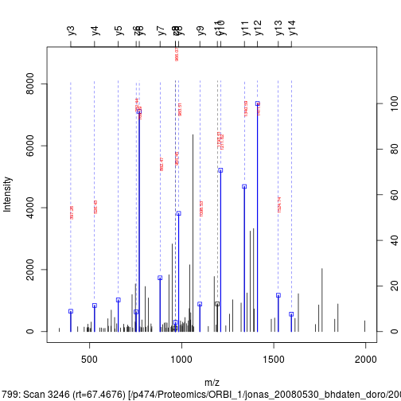

```r
library("protViz")
data(msms)

fi <- fragmentIon("TAFDEAIAELDTLNEESYK")
fi.cyz <- as.data.frame(cbind(c=fi[[1]]$c, y=fi[[1]]$y, z=fi[[1]]$z))

p <- peakplot("TAFDEAIAELDTLNEESYK",
              spec = msms[[1]],
              fi = fi.cyz,
              itol = 0.6,
              ion.axes = FALSE)
```

The `peakplot` function return the annotation of the MSMS spectrum that is plotted:

```r
str(p)
```

```
## List of 7
##  $ mZ.Da.error : num [1:57] 215.3 144.27 -2.8 -17.06 2.03 ...
##  $ mZ.ppm.error: num [1:57] 1808046 758830 -8306 -37724 3501 ...
##  $ idx         : num [1:57] 1 1 1 3 16 24 41 52 67 88 ...
##  $ label       : chr [1:57] "c1" "c2" "c3" "c4" ...
##  $ score       : num -1
##  $ sequence    : chr "TAFDEAIAELDTLNEESYK"
##  $ fragmentIon :'data.frame':    19 obs. of  3 variables:
##   ..$ c: num [1:19] 119 190 337 452 581 ...
##   ..$ y: num [1:19] 147 310 397 526 655 ...
##   ..$ z: num [1:19] 130 293 380 509 638 ...
```